# pandas overview

[figure not shown]

J. Patrick Fischer - [Own work](https://commons.wikimedia.org/wiki/File:Grosser_Panda.JPG) [[CC BY-SA 3.0]](https://creativecommons.org/licenses/by-sa/3.0/)

Links for inspiration:

https://pandas.pydata.org/pandas-docs/stable/  
https://pandas.pydata.org/pandas-docs/stable/getting_started/10min.html  
https://pandas.pydata.org/pandas-docs/stable/getting_started/tutorials.html  
https://pandas.pydata.org/pandas-docs/stable/getting_started/comparison/comparison_with_sql.html  
https://www.learndatasci.com/tutorials/python-pandas-tutorial-complete-introduction-for-beginners/  
https://ourcodingclub.github.io/2018/04/18/pandas-python-intro.html  
https://programminghistorian.org/en/lessons/visualizing-with-bokeh#pandas-overview

## Today

- First look at pandas
- Will go through how things work and a few useful things you can do
- *Might* get on to some data visualisation

# Getting started with pandas

> The library’s name derives from **pan**el **da**ta, a common term for multidimensional data sets encountered in statistics and econometrics.

[McKinney, W. (2011). pandas: a foundational Python library for data analysis and statistics. Python for High Performance and Scientific Computing, 14.](https://www.dlr.de/sc/portaldata/15/resources/dokumente/pyhpc2011/submissions/pyhpc2011_submission_9.pdf)

> pandas is a Python package providing fast, flexible, and expressive data structures designed to make working with “relational” or “labeled” data both easy and intuitive. It aims to be the fundamental high-level building block for doing practical, real world data analysis in Python. Additionally, it has the broader goal of becoming the most powerful and flexible open source data analysis / manipulation tool available in any language.

[pandas docs](https://pandas.pydata.org/pandas-docs/stable/getting_started/overview.html)

## Why pandas?

- Useful for manipulating, cleaning up, augmenting and analysing data
- Great with tabular data
- Embedded in the python environment (which may or may not be useful for you)
- Built on top of NumPy - a mathematical library for Python with some useful applications for analysing your data
- It's (mostly) quite fast, and (mostly) user friendly

## Data structures

- pandas represents a column of tabular data as a **Series** - the 1D case
- multiple columns represented together as a table of data are called a **DataFrame** - 2D case

## When to use pandas

- Best with 'small' datasets ranging from a few MB to a few GB - needs to fit in memory!

## When *not* to use pandas

- "Big data" - datasets over about 100 GB. Clearly too large to fit in memory, use [spark](https://spark.apache.org/) or similar!

## Maybe pandas?

Possible to analyse 'large data' (datasets under about 100 GB) in pandas, although other tools such as [dask](https://dask.org/) exist for this purpose

## Where to find help

- The [pandas documentation](https://pandas.pydata.org/pandas-docs/stable/) is a great first stop for e.g. finding function definitions and usage
- pandas [cheat sheet](http://pandas.pydata.org/Pandas_Cheat_Sheet.pdf)
- See if a similar problem has a solution on [stackoverflow](https://stackoverflow.com/questions/tagged/pandas)
- Google/ask around!

## A few basics

Importing pandas

```python
import pandas as pd
import numpy as np
import openpyxl # for reading/writing to excel files

pd.set_option('display.max_rows', 15)
print("hi")
```

```
hi
```

Creating a dataframe from scratch

```python
data = {'apples': [3,5,2], 'oranges': [5,1,3], 'bananas': [2,6,4]}

purchases=pd.DataFrame(data)
purchases['CustomerID']=["0551","0792","0932"]
purchases=purchases.set_index('CustomerID')
```

```python
purchases
```

| CustomerID | apples | oranges | bananas |
| --- | --- | --- | --- |
| 0551 | 3 | 5 | 2 |
| 0792 | 5 | 1 | 6 |
| 0932 | 2 | 3 | 4 |

Or make a dataframe like this:

```python
df = pd.DataFrame({'A': 1.,
                    'B': pd.Timestamp('20130102'),
                    'C': pd.Series(1, index=list(range(4)), dtype='float32'),
                    'D': np.array([3] * 4, dtype='int32'),
                    'E': pd.Categorical(["test", "train", "test", "train"]),
                    'F': 'foo'
                    })
df
```

|  | A | B | C | D | E | F |
| --- | --- | --- | --- | --- | --- | --- |
| 0 | 1.0 | 2013-01-02 | 1.0 | 3 | test | foo |
| 1 | 1.0 | 2013-01-02 | 1.0 | 3 | train | foo |
| 2 | 1.0 | 2013-01-02 | 1.0 | 3 | test | foo |
| 3 | 1.0 | 2013-01-02 | 1.0 | 3 | train | foo |

```python
np.random.randn(10)
```

```
array([-0.34446723,  0.77390024, -0.68807025,  0.20810817, -0.15254949,
       -0.13204879,  0.33497757,  0.11419316, -0.01687391,  1.87776583])
```

```python
dfL=pd.DataFrame({'A':pd.Series(np.random.randn(10)),
                  'B': pd.Series(np.random.randn(10)),
                  'C': pd.Series(np.random.randn(10))
                 })
dfL.info()
```

```
<class 'pandas.core.frame.DataFrame'>
RangeIndex: 10 entries, 0 to 9
Data columns (total 3 columns):
 #   Column  Non-Null Count  Dtype
---  ------  --------------  -----
 0   A       10 non-null     float64
 1   B       10 non-null     float64
 2   C       10 non-null     float64
dtypes: float64(3)
memory usage: 368.0 bytes
```

```python
dfL.head()
```

|  | A | B | C |
| --- | --- | --- | --- |
| 0 | -1.019292 | 1.758156 | -0.955984 |
| 1 | -1.152441 | -0.529935 | -0.154382 |
| 2 | -0.235078 | 1.970526 | -1.287680 |
| 3 | 0.267712 | 0.190478 | 2.300638 |
| 4 | -0.733550 | 1.097773 | 0.575565 |

```python
dfL.tail()
```

|  | A | B | C |
| --- | --- | --- | --- |
| 5 | -0.156552 | 0.757450 | 0.490211 |
| 6 | 1.152356 | 0.683900 | -0.795218 |
| 7 | 0.910459 | -0.721574 | -0.913458 |
| 8 | -1.129562 | 0.861378 | 0.146310 |
| 9 | -0.353372 | 0.149276 | -0.961154 |

### Saving as a comma separated variable (CSV) file or an excel file

```python
dfL.to_csv('../data/dfl_csv.csv')
```

```python
dfL.to_excel('../data/dfl_excel.xlsx')
```

### Import from csv into dataframe:

```python
csvdf=pd.read_csv('../data/Pandas_example_csv.csv')
csvdf
```

|  | User ID | Join date | Total Sales | Status |
| --- | --- | --- | --- | --- |
| 0 | 7652 | 01/01/2020 | 20 | Staff |
| 1 | 1025 | 01/02/2015 | 110 | Guest |
| 2 | 9856 | 26/04/2017 | 300 | Guest |
| 3 | 11063 | 26/10/2016 | 1100 | Staff |
| 4 | 2314 | 13/01/2019 | 500 | Staff |
| 5 | 6749 | 11/05/2018 | 244 | Guest |
| 6 | 4346 | 26/04/2017 | 213 | Guest |

```python
csvdf['Join date']=pd.to_datetime(csvdf['Join date'])
csvdf
```

|  | User ID | Join date | Total Sales | Status |
| --- | --- | --- | --- | --- |
| 0 | 7652 | 2020-01-01 | 20 | Staff |
| 1 | 1025 | 2015-01-02 | 110 | Guest |
| 2 | 9856 | 2017-04-26 | 300 | Guest |
| 3 | 11063 | 2016-10-26 | 1100 | Staff |
| 4 | 2314 | 2019-01-13 | 500 | Staff |
| 5 | 6749 | 2018-11-05 | 244 | Guest |
| 6 | 4346 | 2017-04-26 | 213 | Guest |

```python
csvdf.dtypes
```

```
User ID                 int64
Join date      datetime64[ns]
Total Sales             int64
Status                 object
dtype: object
```

### ... or Excel files

```python
exceldf=pd.read_excel('../data/Pandas_example_excel.xlsx')
exceldf
```

|  | User ID | Join date | Total Sales | Status |
| --- | --- | --- | --- | --- |
| 0 | 7652 | 2020-01-01 | 20 | Staff |
| 1 | 1025 | 2015-02-01 | 110 | Guest |
| 2 | 9856 | 2017-04-26 | 300 | Guest |
| 3 | 11063 | 2016-10-26 | 1100 | Staff |
| 4 | 2314 | 2019-01-13 | 500 | Staff |
| 5 | 6749 | 2018-05-11 | 244 | Guest |
| 6 | 4346 | 2017-04-26 | 213 | Guest |

### Describing your data

```python
exceldf.dtypes
```

```
User ID                 int64
Join date      datetime64[ns]
Total Sales             int64
Status                 object
dtype: object
```

```python
exceldf.columns
```

```
Index(['User ID ', 'Join date', 'Total Sales', 'Status'], dtype='object')
```

```python
exceldf.columns=exceldf.columns.str.rstrip() # remove any trailing whitespace
exceldf.columns
```

```
Index(['User ID', 'Join date', 'Total Sales', 'Status'], dtype='object')
```

```python
exceldf.describe()
```

|  | User ID | Total Sales |
| --- | --- | --- |
| count | 7.000000 | 7.000000 |
| mean | 6143.571429 | 355.285714 |
| std | 3757.691173 | 361.434510 |
| min | 1025.000000 | 20.000000 |
| 25% | 3330.000000 | 161.500000 |
| 50% | 6749.000000 | 244.000000 |
| 75% | 8754.000000 | 400.000000 |
| max | 11063.000000 | 1100.000000 |

## DataFrame manipulation

```python
exceldf.sort_index(axis=1)
```

|  | Join date | Status | Total Sales | User ID |
| --- | --- | --- | --- | --- |
| 0 | 2020-01-01 | Staff | 20 | 7652 |
| 1 | 2015-02-01 | Guest | 110 | 1025 |
| 2 | 2017-04-26 | Guest | 300 | 9856 |
| 3 | 2016-10-26 | Staff | 1100 | 11063 |
| 4 | 2019-01-13 | Staff | 500 | 2314 |
| 5 | 2018-05-11 | Guest | 244 | 6749 |
| 6 | 2017-04-26 | Guest | 213 | 4346 |

```python
exceldf.sort_values(by='Join date')
```

|  | User ID | Join date | Total Sales | Status |
| --- | --- | --- | --- | --- |
| 1 | 1025 | 2015-02-01 | 110 | Guest |
| 3 | 11063 | 2016-10-26 | 1100 | Staff |
| 2 | 9856 | 2017-04-26 | 300 | Guest |
| 6 | 4346 | 2017-04-26 | 213 | Guest |
| 5 | 6749 | 2018-05-11 | 244 | Guest |
| 4 | 2314 | 2019-01-13 | 500 | Staff |
| 0 | 7652 | 2020-01-01 | 20 | Staff |

### Get a single column

```python
exceldf['Total Sales']
```

```
0      20
1     110
2     300
3    1100
4     500
5     244
6     213
Name: Total Sales, dtype: int64
```

### Get multiple columns

```python
exceldf[['User ID','Total Sales']]
```

|  | User ID | Total Sales |
| --- | --- | --- |
| 0 | 7652 | 20 |
| 1 | 1025 | 110 |
| 2 | 9856 | 300 |
| 3 | 11063 | 1100 |
| 4 | 2314 | 500 |
| 5 | 6749 | 244 |
| 6 | 4346 | 213 |

### Or slice by rows

```python
exceldf[0::3]
```

|  | User ID | Join date | Total Sales | Status |
| --- | --- | --- | --- | --- |
| 0 | 7652 | 2020-01-01 | 20 | Staff |
| 3 | 11063 | 2016-10-26 | 1100 | Staff |
| 6 | 4346 | 2017-04-26 | 213 | Guest |

### Selection by label

```python
exceldf[exceldf['Status']=="Guest"]
```

|  | User ID | Join date | Total Sales | Status |
| --- | --- | --- | --- | --- |
| 1 | 1025 | 2015-02-01 | 110 | Guest |
| 2 | 9856 | 2017-04-26 | 300 | Guest |
| 6 | 4346 | 2017-04-26 | 213 | Guest |

### Conditional selections

```python
exceldf[(exceldf['Join date']>='2018') & (exceldf['Status']=='Staff')]
```

|  | User ID | Join date | Total Sales | Status |
| --- | --- | --- | --- | --- |
| 0 | 7652 | 2020-01-01 | 20 | Staff |
| 4 | 2314 | 2019-01-13 | 500 | Staff |

```python
exceldf[(exceldf['Join date']<'2018') & (exceldf['Status']=='Staff')]
```

|  | User ID | Join date | Total Sales | Status |
| --- | --- | --- | --- | --- |
| 3 | 11063 | 2016-10-26 | 1100 | Staff |

### Change the index of your dataframe

In this case make the index run from 1 to the total number of rows of your dataframe

```python
exceldf.index = np.arange(1,len(exceldf)+1)
exceldf
```

|  | User ID | Join date | Total Sales | Status |
| --- | --- | --- | --- | --- |
| 1 | 7652 | 2020-01-01 | 20 | Staff |
| 2 | 1025 | 2015-02-01 | 110 | Guest |
| 3 | 9856 | 2017-04-26 | 300 | Guest |
| 4 | 11063 | 2016-10-26 | 1100 | Staff |
| 5 | 2314 | 2019-01-13 | 500 | Staff |
| 6 | 6749 | 2018-05-11 | 244 | Guest |
| 7 | 4346 | 2017-04-26 | 213 | Guest |

### Locate row by index value

```python
exceldf.loc[1]
```

```
User ID                       7652
Join date      2020-01-01 00:00:00
Total Sales                     20
Status                       Staff
Name: 1, dtype: object
```

### Locate row by index position (remember first element is 0!)

```python
exceldf.iloc[0]
```

```
User ID                       7652
Join date      2020-01-01 00:00:00
Total Sales                     20
Status                       Staff
Name: 1, dtype: object
```

### Adding a new column (length of values much match length of index)

```python
mailingList=['Yes','No','No','No',np.nan,'Yes','No']
exceldf['Signed up for Mailing List?']=mailingList
exceldf
```

|  | User ID | Join date | Total Sales | Status | Signed up for Mailing List? |
| --- | --- | --- | --- | --- | --- |
| 1 | 7652 | 2020-01-01 | 20 | Staff | Yes |
| 2 | 1025 | 2015-02-01 | 110 | Guest | No |
| 3 | 9856 | 2017-04-26 | 300 | Guest | No |
| 4 | 11063 | 2016-10-26 | 1100 | Staff | No |
| 5 | 2314 | 2019-01-13 | 500 | Staff | NaN |
| 6 | 6749 | 2018-05-11 | 244 | Guest | Yes |
| 7 | 4346 | 2017-04-26 | 213 | Guest | No |

Can also find missing data in DataFrames, replace it with a value of your choice

```python
exceldf=exceldf.fillna("No")
exceldf
```

|  | User ID | Join date | Total Sales | Status | Signed up for Mailing List? |
| --- | --- | --- | --- | --- | --- |
| 1 | 7652 | 2020-01-01 | 20 | Staff | Yes |
| 2 | 1025 | 2015-02-01 | 110 | Guest | No |
| 3 | 9856 | 2017-04-26 | 300 | Guest | No |
| 4 | 11063 | 2016-10-26 | 1100 | Staff | No |
| 5 | 2314 | 2019-01-13 | 500 | Staff | No |
| 6 | 6749 | 2018-05-11 | 244 | Guest | Yes |
| 7 | 4346 | 2017-04-26 | 213 | Guest | No |

```python
exceldf['Status'].str.lower()
```

```
1     staff
2     guest
3     guest
4     staff
5     staff
6    guest
7     guest
Name: Status, dtype: object
```

### Merging dataframes

Dataframes can be merged (similar to SQL join operations - see [this link](https://pandas.pydata.org/pandas-docs/stable/getting_started/comparison/comparison_with_sql.html) for more SQL-equivalent functionality!)

Concatenate two dataframes:

```python
df = pd.DataFrame({'User ID': '232', 'Join date': pd.Timestamp('20120502'),
                   'Total Sales': '2000','Status': 'Staff','Signed up for Mailing List?': 'No'
                  }, index=[0])
df
```

|  | User ID | Join date | Total Sales | Status | Signed up for Mailing List? |
| --- | --- | --- | --- | --- | --- |
| 0 | 232 | 2012-05-02 | 2000 | Staff | No |

```python
pd.concat([exceldf,df]).tail(5)
```

|  | User ID | Join date | Total Sales | Status | Signed up for Mailing List? |
| --- | --- | --- | --- | --- | --- |
| 4 | 11063 | 2016-10-26 | 1100 | Staff | No |
| 5 | 2314 | 2019-01-13 | 500 | Staff | No |
| 6 | 6749 | 2018-05-11 | 244 | Guest | Yes |
| 7 | 4346 | 2017-04-26 | 213 | Guest | No |
| 0 | 232 | 2012-05-02 | 2000 | Staff | No |

Import a second csv as a dataframe:

```python
exceldf2=pd.read_csv("../data/Pandas_example_extra_csv.csv")
exceldf2
```

|  | User ID | Status | Age |
| --- | --- | --- | --- |
| 0 | 7652 | Staff | 37 |
| 1 | 1025 | Guest | 54 |
| 2 | 9856 | Guest | 29 |
| 3 | 11063 | Staff | 62 |
| 4 | 2314 | Staff | 35 |
| 5 | 6749 | Guest | 44 |
| 6 | 4346 | Guest | 32 |

```python
exceldf2.columns=exceldf2.columns.str.rstrip()
```

Perform a join-style merge

```python
mergedDF=pd.merge(exceldf, exceldf2, on=['User ID','Status'])
mergedDF
```

|  | User ID | Join date | Total Sales | Status | Signed up for Mailing List? | Age |
| --- | --- | --- | --- | --- | --- | --- |
| 0 | 7652 | 2020-01-01 | 20 | Staff | Yes | 37 |
| 1 | 1025 | 2015-02-01 | 110 | Guest | No | 54 |
| 2 | 9856 | 2017-04-26 | 300 | Guest | No | 29 |
| 3 | 11063 | 2016-10-26 | 1100 | Staff | No | 62 |
| 4 | 2314 | 2019-01-13 | 500 | Staff | No | 35 |
| 5 | 6749 | 2018-05-11 | 244 | Guest | Yes | 44 |
| 6 | 4346 | 2017-04-26 | 213 | Guest | No | 32 |

Make the User ID column the index

```python
mergedDF.set_index("User ID", drop = True, inplace = True)
mergedDF
```

| User ID | Join date | Total Sales | Status | Signed up for Mailing List? | Age |
| --- | --- | --- | --- | --- | --- |
| 7652 | 2020-01-01 | 20 | Staff | Yes | 37 |
| 1025 | 2015-02-01 | 110 | Guest | No | 54 |
| 9856 | 2017-04-26 | 300 | Guest | No | 29 |
| 11063 | 2016-10-26 | 1100 | Staff | No | 62 |
| 2314 | 2019-01-13 | 500 | Staff | No | 35 |
| 6749 | 2018-05-11 | 244 | Guest | Yes | 44 |
| 4346 | 2017-04-26 | 213 | Guest | No | 32 |

### Grouping dataframes

```python
mergedDF.groupby("Status").mean()
```

| Status | Total Sales | Age |
| --- | --- | --- |
| Guest | 207.666667 | 38.333333 |
| Guest | 244.000000 | 44.000000 |
| Staff | 540.000000 | 44.666667 |

`Guest` appears twice, why?

```python
mergedDF['Status'].to_numpy() # converts pandas Series to numpy array
```

```
array(['Staff', 'Guest', 'Guest', 'Staff', 'Staff', 'Guest ', 'Guest'],
      dtype=object)
```

One of the entries has trailing whitespace, so remove it

```python
mergedDF['Status']=mergedDF['Status'].str.rstrip() # convert mergedDF['Status'] to strings before removing trailing whitespace
mergedDF['Status'].to_numpy()
```

```
array(['Staff', 'Guest', 'Guest', 'Staff', 'Staff', 'Guest', 'Guest'],
      dtype=object)
```

```python
mergedDF.groupby("Status").mean()
```

| Status | Total Sales | Age |
| --- | --- | --- |
| Guest | 216.75 | 39.750000 |
| Staff | 540.00 | 44.666667 |

Set float precision to 2 decimal places

```python
pd.options.display.float_format = '{:.2f}'.format
mdfMeans=mergedDF.groupby("Status").mean()
mdfMeans
```

| Status | Total Sales | Age |
| --- | --- | --- |
| Guest | 216.75 | 39.75 |
| Staff | 540.00 | 44.67 |

### Can also append rows to your dataframe

```python
extraRows=pd.DataFrame({'User ID': np.arange(1,50),
                       'Join date':pd.Timestamp('20100301'),
                       'Total Sales': np.random.random_sample(49)*3000.,
                       'Status': 'Staff',
                       'Signed up for Mailing List?': 'Yes',
                       })
extraRows.set_index("User ID", drop = True, inplace = True)
extraRows.head(5)
```

| User ID | Join date | Total Sales | Status | Signed up for Mailing List? |
| --- | --- | --- | --- | --- |
| 1 | 2010-03-01 | 1673.87 | Staff | Yes |
| 2 | 2010-03-01 | 1913.60 | Staff | Yes |
| 3 | 2010-03-01 | 869.73 | Staff | Yes |
| 4 | 2010-03-01 | 1991.15 | Staff | Yes |
| 5 | 2010-03-01 | 2330.56 | Staff | Yes |

```python
largeDF=mergedDF.append(extraRows)
largeDF
```

| User ID | Join date | Total Sales | Status | Signed up for Mailing List? | Age |
| --- | --- | --- | --- | --- | --- |
| 7652 | 2020-01-01 | 20.00 | Staff | Yes | 37.00 |
| 1025 | 2015-02-01 | 110.00 | Guest | No | 54.00 |
| 9856 | 2017-04-26 | 300.00 | Guest | No | 29.00 |
| 11063 | 2016-10-26 | 1100.00 | Staff | No | 62.00 |
| 2314 | 2019-01-13 | 500.00 | Staff | No | 35.00 |
| ... | ... | ... | ... | ... | ... |
| 45 | 2010-03-01 | 1551.72 | Staff | Yes | nan |
| 46 | 2010-03-01 | 1916.84 | Staff | Yes | nan |
| 47 | 2010-03-01 | 15.82 | Staff | Yes | nan |
| 48 | 2010-03-01 | 1366.48 | Staff | Yes | nan |
| 49 | 2010-03-01 | 586.34 | Staff | Yes | nan |

56 rows × 5 columns

Ages are mising, so can drop rows with no value, age column entirely or replace the nan values

```python
largeDF.dropna(axis=1)
```

| User ID | Join date | Total Sales | Status | Signed up for Mailing List? |
| --- | --- | --- | --- | --- |
| 7652 | 2020-01-01 | 20.00 | Staff | Yes |
| 1025 | 2015-02-01 | 110.00 | Guest | No |
| 9856 | 2017-04-26 | 300.00 | Guest | No |
| 11063 | 2016-10-26 | 1100.00 | Staff | No |
| 2314 | 2019-01-13 | 500.00 | Staff | No |
| ... | ... | ... | ... | ... |
| 45 | 2010-03-01 | 1551.72 | Staff | Yes |
| 46 | 2010-03-01 | 1916.84 | Staff | Yes |
| 47 | 2010-03-01 | 15.82 | Staff | Yes |
| 48 | 2010-03-01 | 1366.48 | Staff | Yes |
| 49 | 2010-03-01 | 586.34 | Staff | Yes |

56 rows × 4 columns

```python
largeDF=largeDF.fillna(largeDF['Age'].mean())
largeDF
```

| User ID | Join date | Total Sales | Status | Signed up for Mailing List? | Age |
| --- | --- | --- | --- | --- | --- |
| 7652 | 2020-01-01 | 20.00 | Staff | Yes | 37.00 |
| 1025 | 2015-02-01 | 110.00 | Guest | No | 54.00 |
| 9856 | 2017-04-26 | 300.00 | Guest | No | 29.00 |
| 11063 | 2016-10-26 | 1100.00 | Staff | No | 62.00 |
| 2314 | 2019-01-13 | 500.00 | Staff | No | 35.00 |
| ... | ... | ... | ... | ... | ... |
| 45 | 2010-03-01 | 1551.72 | Staff | Yes | 41.86 |
| 46 | 2010-03-01 | 1916.84 | Staff | Yes | 41.86 |
| 47 | 2010-03-01 | 15.82 | Staff | Yes | 41.86 |
| 48 | 2010-03-01 | 1366.48 | Staff | Yes | 41.86 |
| 49 | 2010-03-01 | 586.34 | Staff | Yes | 41.86 |

56 rows × 5 columns

Randomly sample values from your dataframe:

```python
largeDF.sample(5)
```

| Join date | Total Sales | Status | Signed up for Mailing List? | Age |
| --- | --- | --- | --- | --- |
| 2010-03-01 | 2864.80 | Staff | Yes | 41.86 |
| 2010-03-01 | 1341.21 | Staff | Yes | 41.86 |
| 2010-03-01 | 2297.02 | Staff | Yes | 41.86 |
| 2010-03-01 | 2859.67 | Staff | Yes | 41.86 |
| 2010-03-01 | 2016.74 | Staff | Yes | 41.86 |

### Basic Plotting

```python
largeDF
```

| User ID | Join date | Total Sales | Status | Signed up for Mailing List? | Age |
| --- | --- | --- | --- | --- | --- |
| 7652 | 2020-01-01 | 20.00 | Staff | Yes | 37.00 |
| 1025 | 2015-02-01 | 110.00 | Guest | No | 54.00 |
| 9856 | 2017-04-26 | 300.00 | Guest | No | 29.00 |
| 11063 | 2016-10-26 | 1100.00 | Staff | No | 62.00 |
| 2314 | 2019-01-13 | 500.00 | Staff | No | 35.00 |
| ... | ... | ... | ... | ... | ... |
| 45 | 2010-03-01 | 1551.72 | Staff | Yes | 41.86 |
| 46 | 2010-03-01 | 1916.84 | Staff | Yes | 41.86 |
| 47 | 2010-03-01 | 15.82 | Staff | Yes | 41.86 |
| 48 | 2010-03-01 | 1366.48 | Staff | Yes | 41.86 |
| 49 | 2010-03-01 | 586.34 | Staff | Yes | 41.86 |

56 rows × 5 columns

Could get the total sales value over time

```python
largeDF=largeDF.set_index('Join date').sort_index()
```

```python
largeDF['Total Sales'].cumsum()
```

```
Join date
2010-03-01    1519.26
2010-03-01    4384.06
2010-03-01    4653.59
2010-03-01    6510.04
2010-03-01    7405.18
               ...
2017-04-26   75752.52
2017-04-26   76052.52
2018-05-11   76296.52
2019-01-13   76796.52
2020-01-01   76816.52
Name: Total Sales, Length: 56, dtype: float64
```

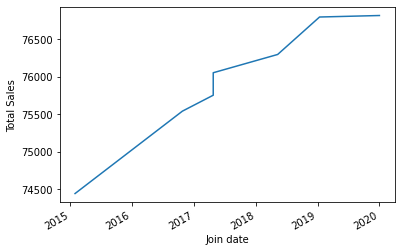

```python
largeDF['Total Sales'].cumsum()[-7::].plot().set_ylabel("Total Sales") # get the cumulative sales from each member over time from 2015 onwards and plot
```

pandas `.plot()` convenience function relies on matplotlib, a popular data visualisation library in python

Or could plot a histogram of the age distribution...

```python
largeDF['Age']
```

```
Join date
2010-03-01   41.86
2010-03-01   41.86
2010-03-01   41.86
2010-03-01   41.86
2010-03-01   41.86
              ...
2017-04-26   32.00
2017-04-26   29.00
2018-05-11   44.00
2019-01-13   35.00
2020-01-01   37.00
Name: Age, Length: 56, dtype: float64
```

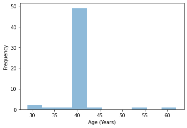

```python
largeDF['Age'].plot.hist(bins=10, alpha=0.5).set_xlabel("Age (Years)")
```